# Data Science Test

Miguel Pereira

10 April 2020

## Introduction

This document describes the approach taken to build a model to predict the presence of heart disease. It uses the processed Cleveleand dataset where the outcome is a classification of whether the patient has heart disease (values 1,2,3,4) or not (value 0).

I will approach this problem as a binary classification problem (presence vs. absence of heart disease) and will use the other variables as predictors.

I will take a supervised learning approach to predict heart disease (option 1).

The following document is organised as follows:

1. Descriptive statistics
2. Statistical Modelling
3. Model interpretation and concluding remarks

## Descriptive statistics

First, the data will be loaded and I will see how the outcome is distributed across the 5 categories. The dataset has 303 observations (patients) and 14 variables, including the outcome.

Below is a summary of the data a table with the counts of per each outcome class and a table with the counts per class after converting the outcome to a binary variable (0 vs. 1,2,3,4, absense vs. presence of heart disease):

```
##       age        sex     cp         trestbps          chol       fbs
##  Min.   :29.00   0: 97   1: 23   Min.   : 94.0   Min.   :126.0   0:258
##  1st Qu.:48.00   1:206   2: 50   1st Qu.:120.0   1st Qu.:211.0   1: 45
##  Median :56.00           3: 86   Median :130.0   Median :241.0
##  Mean   :54.44           4:144   Mean   :131.7   Mean   :246.7
##  3rd Qu.:61.00                   3rd Qu.:140.0   3rd Qu.:275.0
##  Max.   :77.00                   Max.   :200.0   Max.   :564.0
##
##  restecg    thalach      exang      oldpeak         slope
##  0:151   Min.   : 71.0   0:204   Min.   :0.00   Min.   :1.000
##  1:  4   1st Qu.:133.5   1: 99   1st Qu.:0.00   1st Qu.:1.000
##  2:148   Median :153.0           Median :0.80   Median :2.000
##          Mean   :149.6           Mean   :1.04   Mean   :1.601
##          3rd Qu.:166.0           3rd Qu.:1.60   3rd Qu.:2.000
##          Max.   :202.0           Max.   :6.20   Max.   :3.000
##
##        ca           thal        outcome       outcome.bin
##  Min.   :0.0000   3   :166   Min.   :0.0000   no :164
##  1st Qu.:0.0000   6   : 18   1st Qu.:0.0000   yes:139
##  Median :0.0000   7   :117   Median :0.0000
##  Mean   :0.6722   NA's:  2   Mean   :0.9373
##  3rd Qu.:1.0000              3rd Qu.:2.0000
##  Max.   :3.0000              Max.   :4.0000
##  NA's   :4
```

Counts per class

| Class | Freq |
| --- | --- |
| 0 | 164 |
| 1 | 55 |
| 2 | 36 |
| 3 | 35 |
| 4 | 13 |

Counts per class after converting to binary outcome

| Class | Freq |
| --- | --- |
| no | 164 |
| yes | 139 |

### Box plots of continuous variables by presense of heart disease

#### age

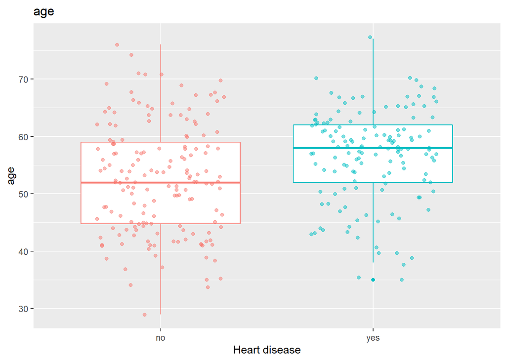

#### trestbps

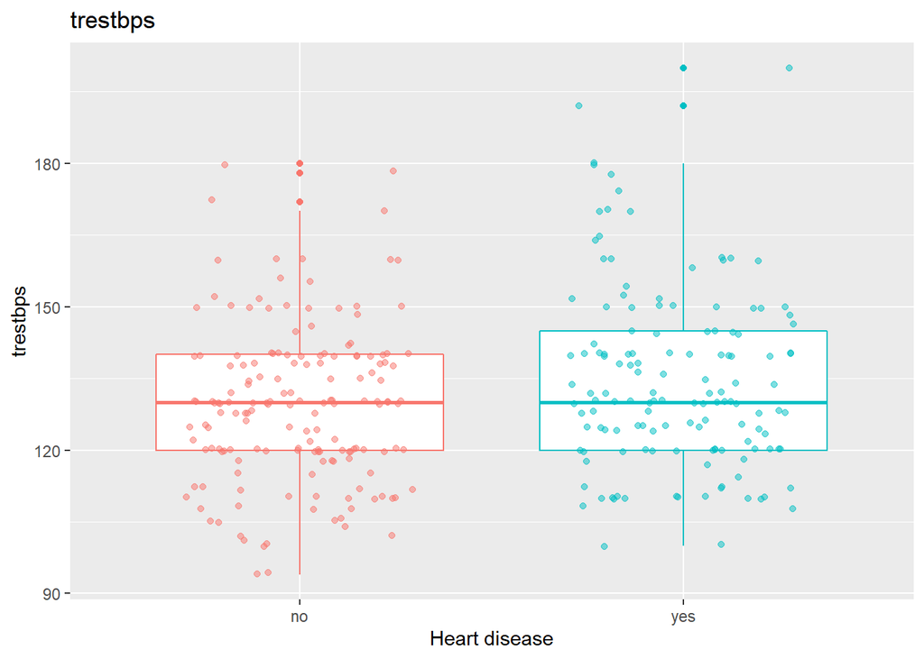

#### chol

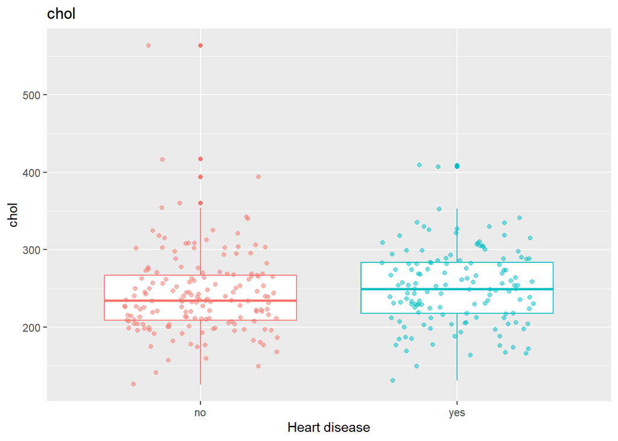

#### thalach

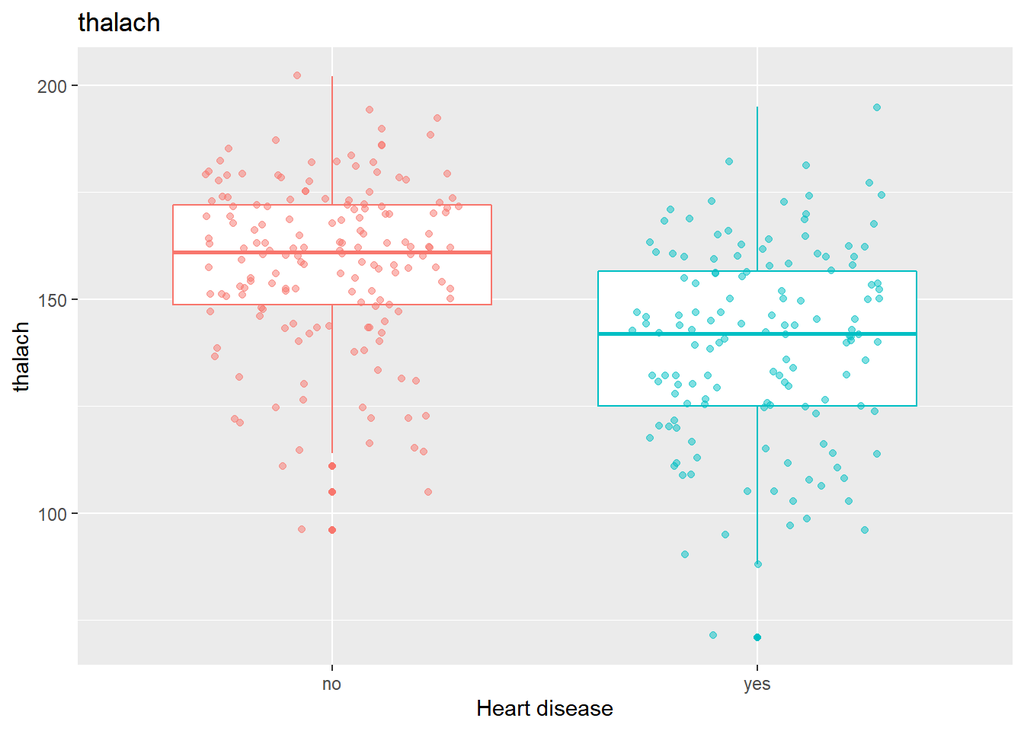

#### oldpeak

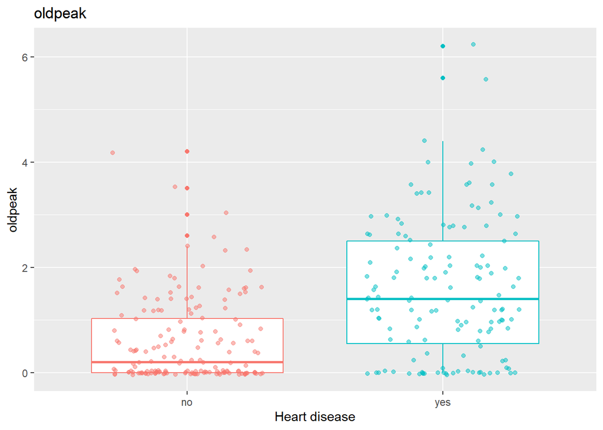

#### slope

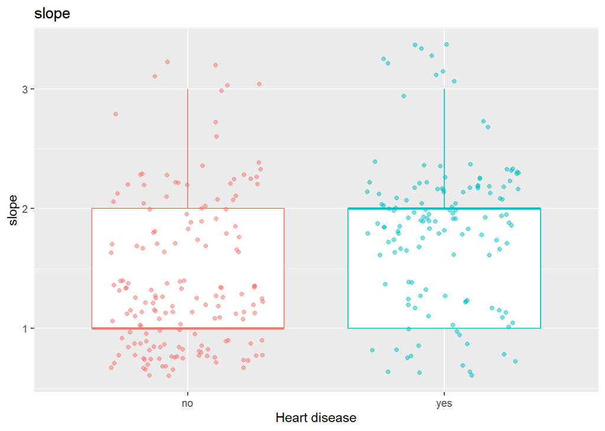

#### ca

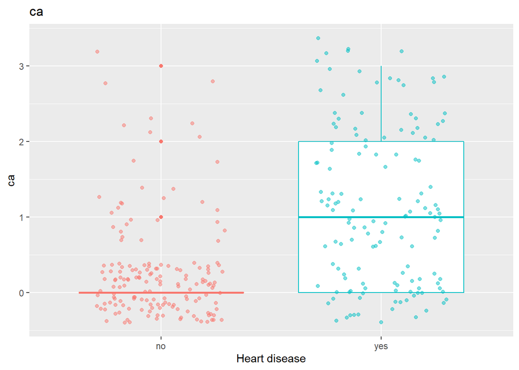

### Bar plots of categorical variables by presense of heart disease

#### sex

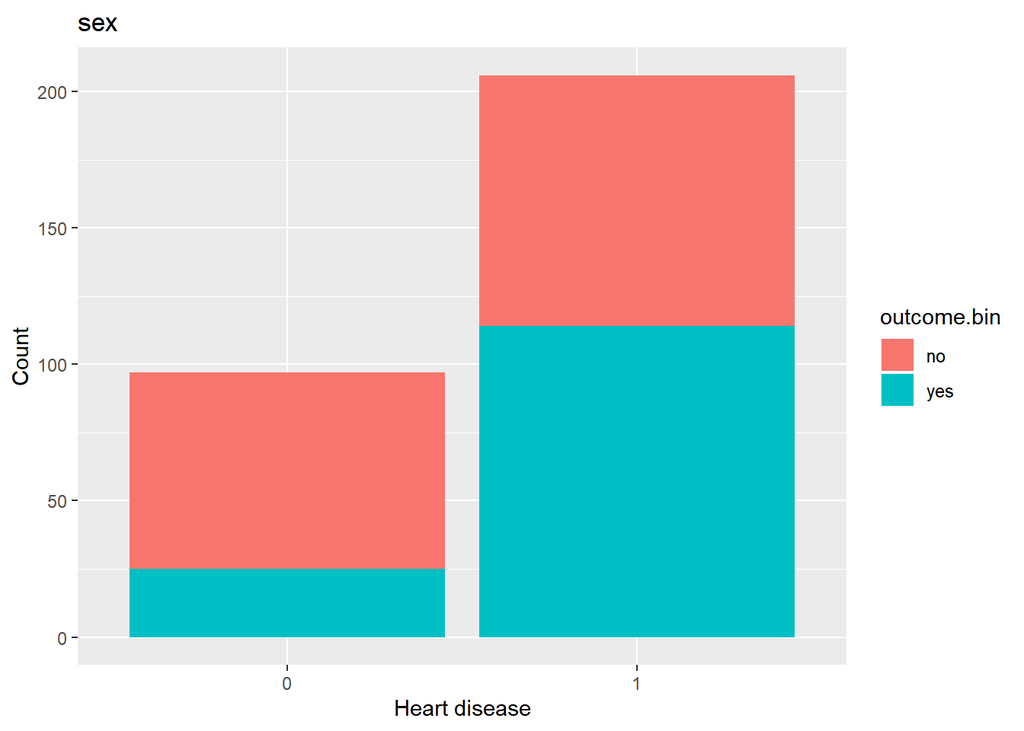

#### cp

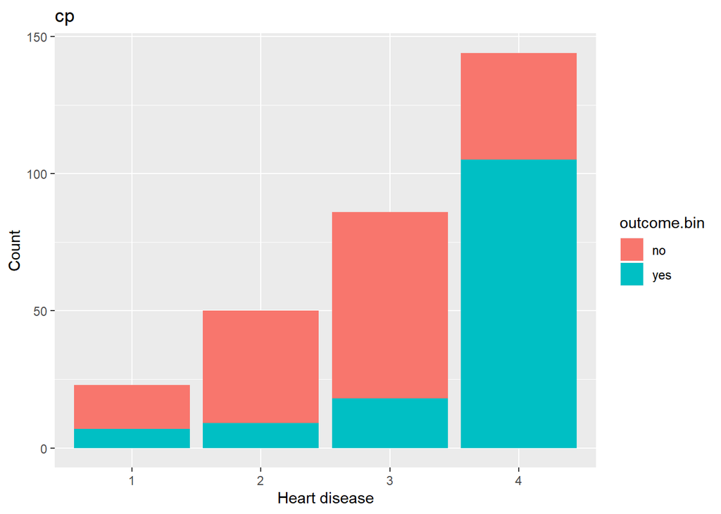

#### fbs

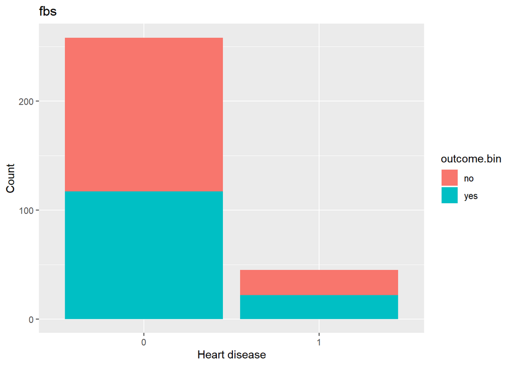

#### restecg

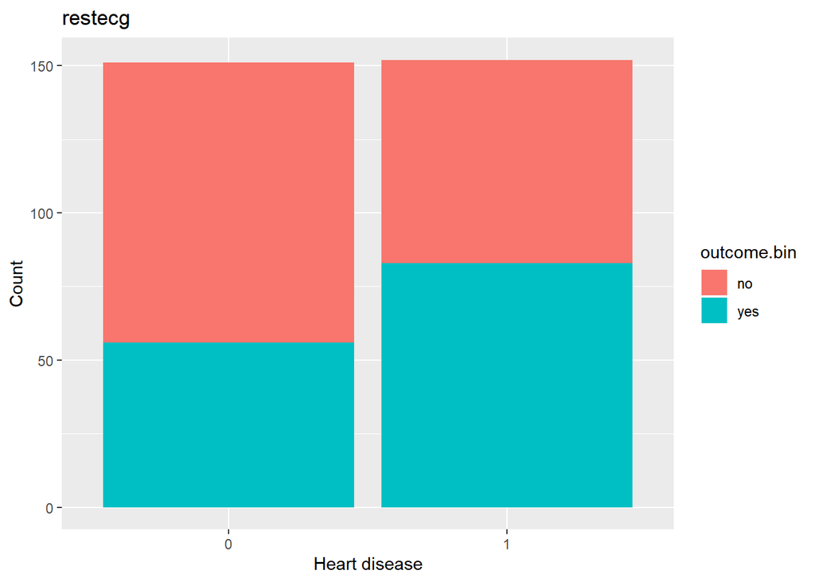

#### exang

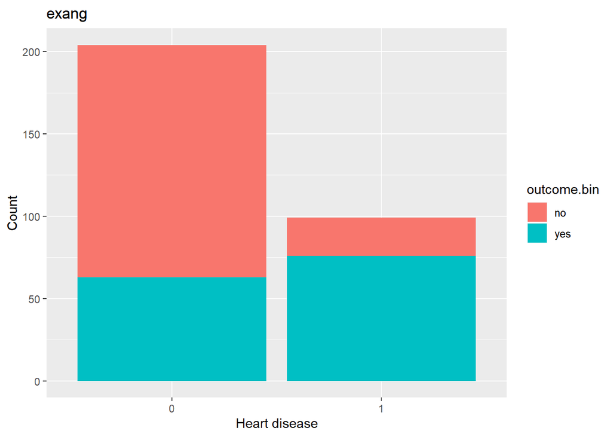

#### thal

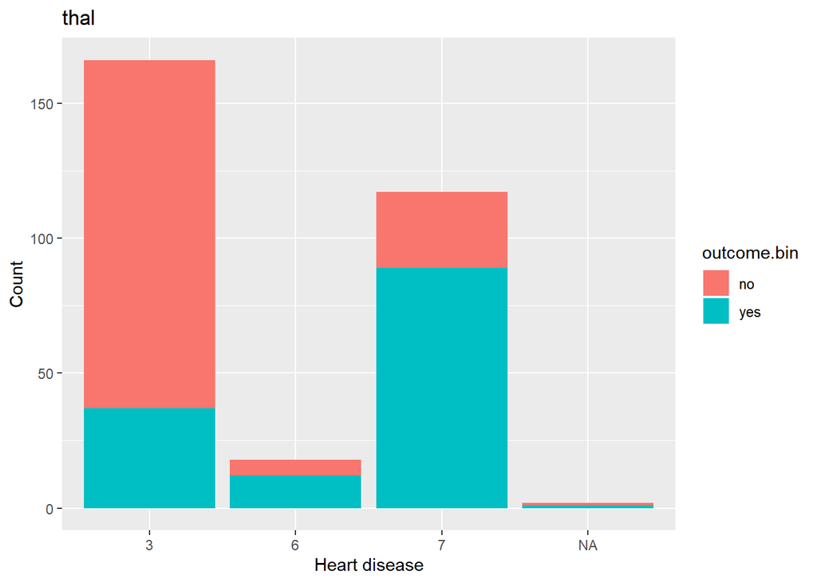

## Statistical Modelling

### Dataset preparation

The goal of this exercise is to create a predictive model of heart disease using the 13 predictors provided. The ideal model will fit the data well while ensuring generalisability to other datasets. With this in mind, I will split the dataset in two parts: a training set (70% of the data) and a test set (30% of the data). The training set will be used to build the model and the test set will be used for external validation. The split will be done such that the proportion of patients with and without heart disease is the same in the two sets.

In addition, the data matrix wil be transformed by creating dummy variables for the factor variables with more than two categories.

The table below shows the number of patients in each category in the train, test and the entire datasets.

Number of patients per outcome category after train-test split

| Training set | Test set | Original data |
| --- | --- | --- |
| 115 | 49 | 164 |
| 98 | 41 | 139 |

### Predictive modelling

For this exercise, I will fit two models to the training set and test their performance in the test set:

1. Elastic net, a linear model that uses regularised regression. The number of patients is larger than the number of predictors but regularisation will be useful to select the important predictors.
2. Support Vector Machines with a radial kernel, a non-linear approach which is useful if there are non-linear relationships between the outcome and predictors.

For both models, accuracy will be used to assess model performance. All the predictors will be standardised and the missing values will be imputed using the k-nearest neighbors (KNN) method.

For hyperparameter tuning and model selection during training, I will use repeated 10-fold cross-validation with 10 repeats. This is something that can be explored in a more in-depth analysis but for conciseness, I will use only these parameters.

### Model performance

In this exercise, accuracy was used as the performance measure for model selection during training. In order to access the performance of the model in the test set, I will also calculate accuracy in the test set and evaluate the AUC.

The following table shows the cross-validation (CV) accuracy, the test accuracy and the AUC for the two models.

Model performence

| Model | Train accuracy | Test accuracy | AUC |
| --- | --- | --- | --- |
| Elastic net | 0.84 | 0.83 | 0.92 |
| SVM - radial kernel | 0.83 | 0.81 | 0.92 |

### Variable importance

Below are the variable importance plots with the variables ordered from most important to least important in both models. For elastic net, it is also possible to see the variables that were left out.

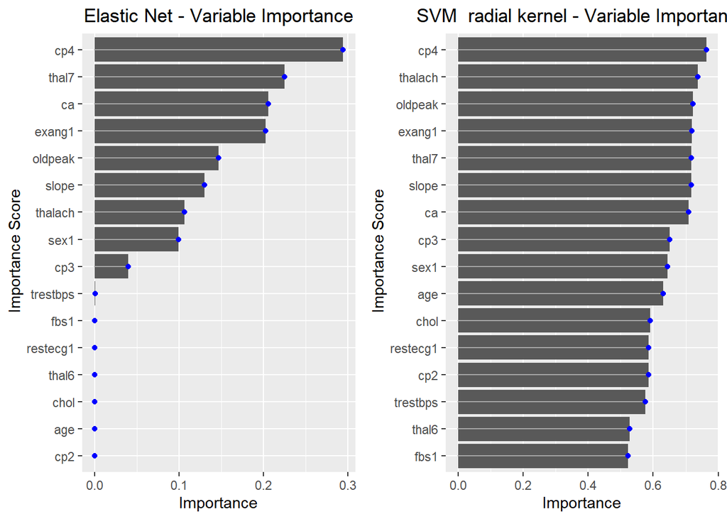

### ROC curves

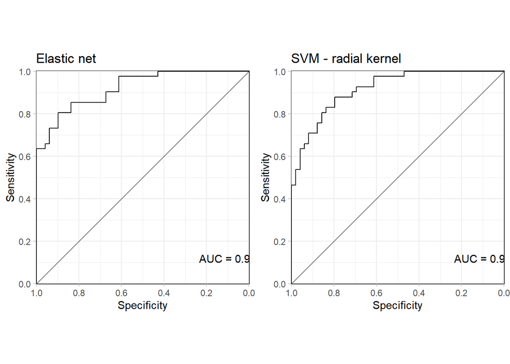

## Model interpretation and concluding remarks

This was a quick approach to a classification problem. For simplicity, the problem was framed as a binary classification problem but it could be extented to a multi-class classification task. This has the caveat that performance would decrease due to lower numbers per class and due to the number of predictors being quite small to predict 5 classes.

This was a supervised learning approach which could be complemented by using unsupervised learning methods (like PCA, for example) to better understand how the predictors correlate with each other. In this case, PCA would not be particularly useful for dimentionality reduction because the number of predictors is not very large for the number of subjects.